# Linear Regression for Prediction, Smoothing, and Working with Matrices Overview

## Linear regressionm

```r
library(tidyverse)
library(caret)
```

```r
library(dslabs)
library(e1071)
library(HistData)
set.seed(2019)
galtonHeights <- GaltonFamilies %>%
  filter(gender == "male") %>%
  group_by(family) %>%
  sample_n(1) %>%
  ungroup() %>%
  select(father, childHeight) %>%
  rename(son = childHeight)
```

Train & Test sets

```r
y <- galtonHeights$son
testIndex <- createDataPartition(y, times = 1, p = 0.5, list = FALSE)

trainSet <- galtonHeights %>% slice(-testIndex)
testSet <- galtonHeights %>% slice(testIndex)
```

Guessing son’s height

```r
avg <- mean(trainSet$son)
```

So, *R squared loss*

```r
mean((avg - testSet$son) ^ 2)
```

```
## [1] 7.074771
```

**Least squares - The Linear regression model**

```r
fit <- lm(son ~ father, data = trainSet)
fit$coef
```

```
## (Intercept)      father
##  45.8729391   0.3403686
```

So, *R squared loss*

```r
yHat <- fit$coef[1] + fit$coef[2] * testSet$father
mean((yHat - testSet$son) ^ 2)
```

```
## [1] 5.144113
```

## Predict function

Create linear regression

```r
yHat <- predict(fit, testSet)
mean((yHat - testSet$son) ^ 2)
```

```
## [1] 5.144113
```

This is the same as the last point

Each predict function may change. Check for help

## Regression for a Categorical Outcome

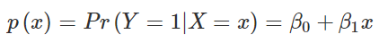

Categorical lineal regression

Get train & test data sets

```r
library(dslabs)
data("heights")
y <- heights$height

set.seed(2)

test_index <- createDataPartition(y, times = 1, p = 0.5, list = FALSE)
train_set <- heights %>% slice(-test_index)
test_set <- heights %>% slice(test_index)

train_set %>%
  filter(round(height)==66) %>%
  summarize(y_hat = mean(sex=="Female"))
```

```
##       y_hat
## 1 0.3269231
```

Create a cutoff for different heights

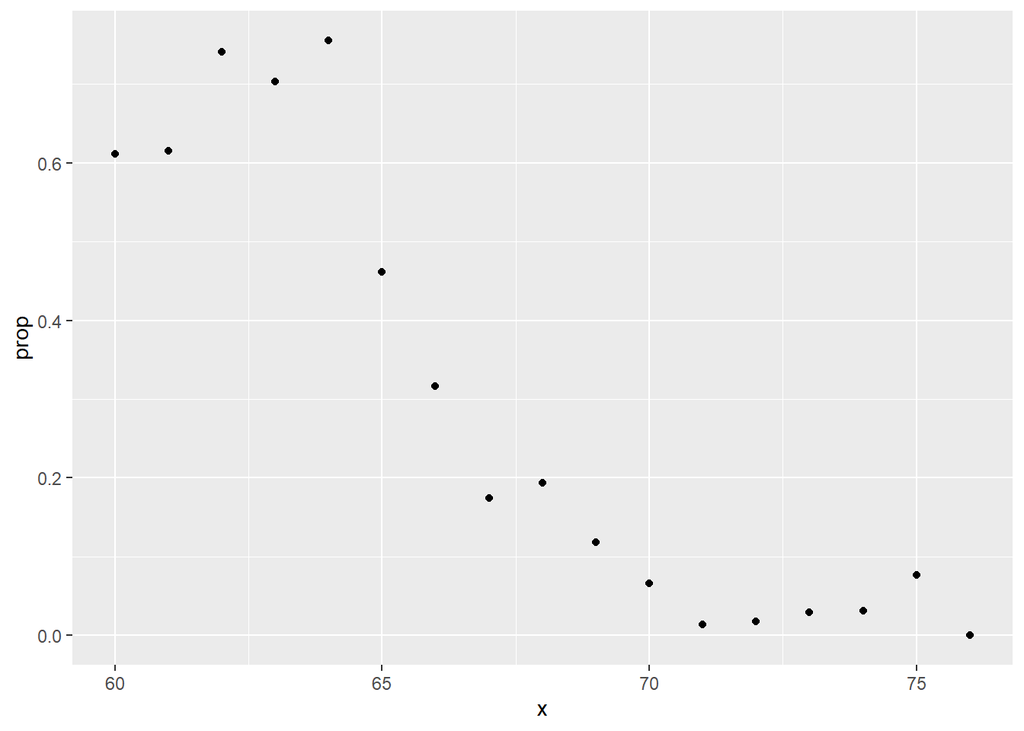

```r
heights %>%
  mutate(x = round(height)) %>%
  group_by(x) %>%
  filter(n() >= 10) %>%
  summarize(prop = mean(sex == "Female")) %>%
  ggplot(aes(x, prop)) +
  geom_point()
```

```r
lm_fit <- mutate(train_set, y = as.numeric(sex == "Female")) %>% lm(y ~ height, data = .)
p_hat <- predict(lm_fit, test_set)
y_hat <- ifelse(p_hat > 0.5, "Female", "Male") %>% factor()
confusionMatrix(y_hat, test_set$sex)$overall["Accuracy"]
```

```
##  Accuracy
## 0.7984791
```

## Logistic Regression

- Assures the estimate of the conditional probability is between 0 & 1
- Turns probabilities to be symmetric around 0
- **Maximum likehood estimate**

```r
glm_fit <- train_set %>%
  mutate(y = as.numeric(sex == "Female")) %>%
  glm(y ~ height, data = ., family = "binomial") # Family is new!
```

**GLM**: Generalized Linear Models

```r
p_hat_logit <- predict(glm_fit, newdata = test_set, type = "response")
```

Results:

```r
y_hat_logit <- ifelse(p_hat_logit > 0.5, "Female", "Male") %>% factor
confusionMatrix(y_hat_logit, test_set$sex)$overall[["Accuracy"]]
```

```
## [1] 0.8174905
```

## Case study

Look for digits, having:

- 4 blocks for the number
- 2 features: Upper left (*x_1*) & lower right (*x_2*) from the digits division

```r
data("mnist_27")
fit <- glm(y ~ x_1 + x_2, data = mnist_27$train, family = "binomial")
```

Get predictions with **testSet**

```r
pHat <- predict(fit, newdata = mnist_27$test)
yHat <- factor(ifelse(pHat > 0.5, 7, 2))
confusionMatrix(data = yHat, reference = mnist_27$test$y)
```

```
## Confusion Matrix and Statistics
##
##           Reference
## Prediction  2  7
##          2 92 34
##          7 14 60
##
##                Accuracy : 0.76
##                  95% CI : (0.6947, 0.8174)
##     No Information Rate : 0.53
##     P-Value [Acc > NIR] : 1.668e-11
##
##                   Kappa : 0.5124
##
##  Mcnemar's Test P-Value : 0.006099
##
##             Sensitivity : 0.8679
##             Specificity : 0.6383
##          Pos Pred Value : 0.7302
##          Neg Pred Value : 0.8108
##              Prevalence : 0.5300
##          Detection Rate : 0.4600
##    Detection Prevalence : 0.6300
##       Balanced Accuracy : 0.7531
##
##        'Positive' Class : 2
##
```

Plot conditional probabilities

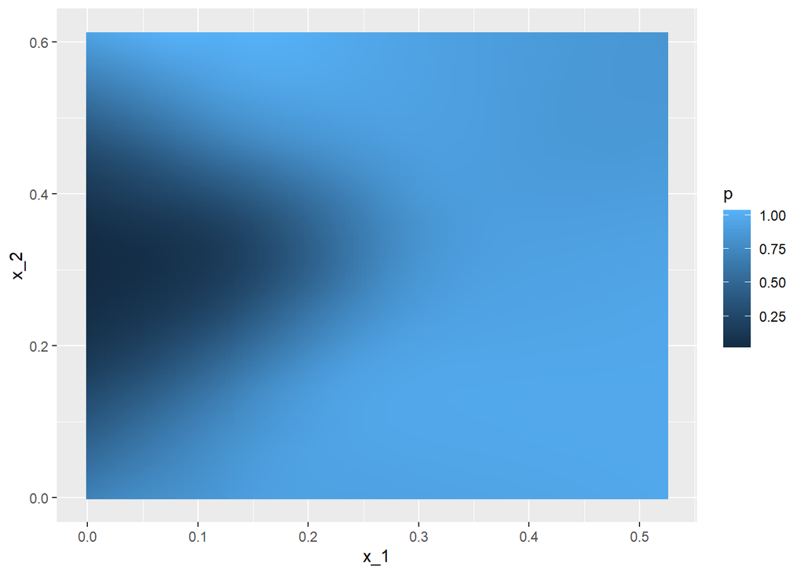

```r
mnist_27$true_p %>% ggplot(aes(x_1, x_2, fill=p)) +
  geom_raster()
```

Plot conditional probabilities *with separates pairs of X1 & X2* Conditional probability is bigger than 0.5 and lower than 0.5

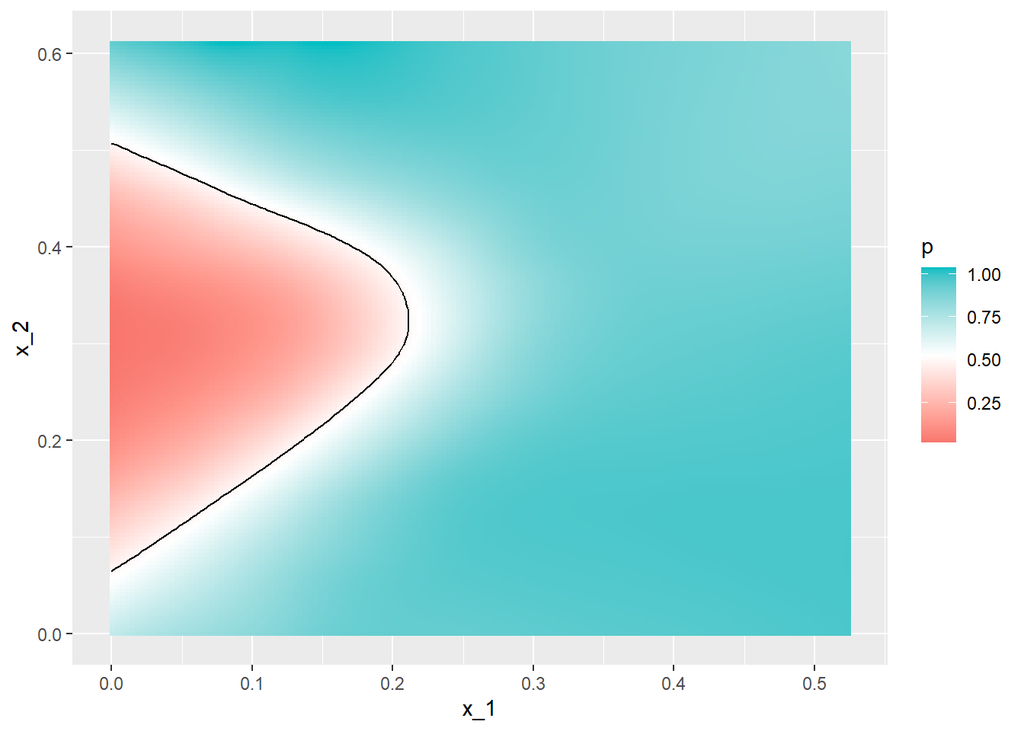

```r
mnist_27$true_p %>% ggplot(aes(x_1, x_2, z = p, fill=p)) +
  geom_raster() +
  scale_fill_gradientn(colors = c("#F8766D", "white", "#00BFC4")) +
  stat_contour(breaks = c(0.5), color = "black")
```

Here, the logistics regression forces the estimates to be a plane and our boundary to be a line. There might be other methods to solve this conflict.

## Introduction to Smoothing

To detect trends in the presence of noisy data where the shape of the trend is unknown

Poll votes from USA

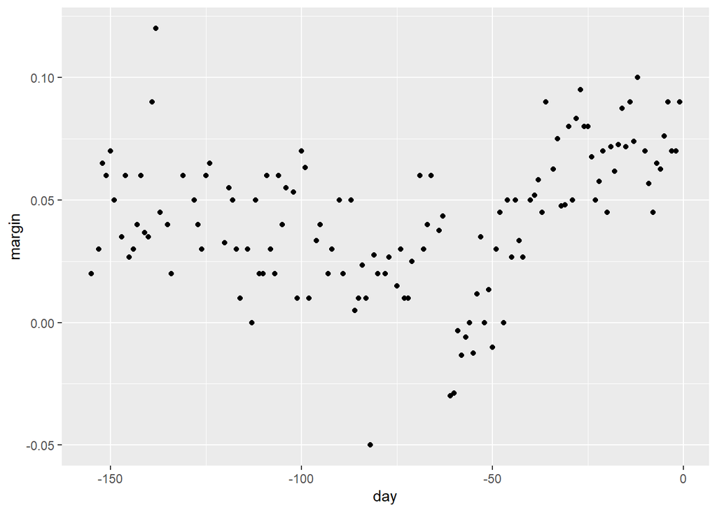

```r
data("polls_2008")
qplot(day, margin, data = polls_2008)
```

Estimate the conditional probability of y depending on x. ie, *f(x) = E(Y | X = x)*.

It’s no OK a straight line. There’s a lack of fit

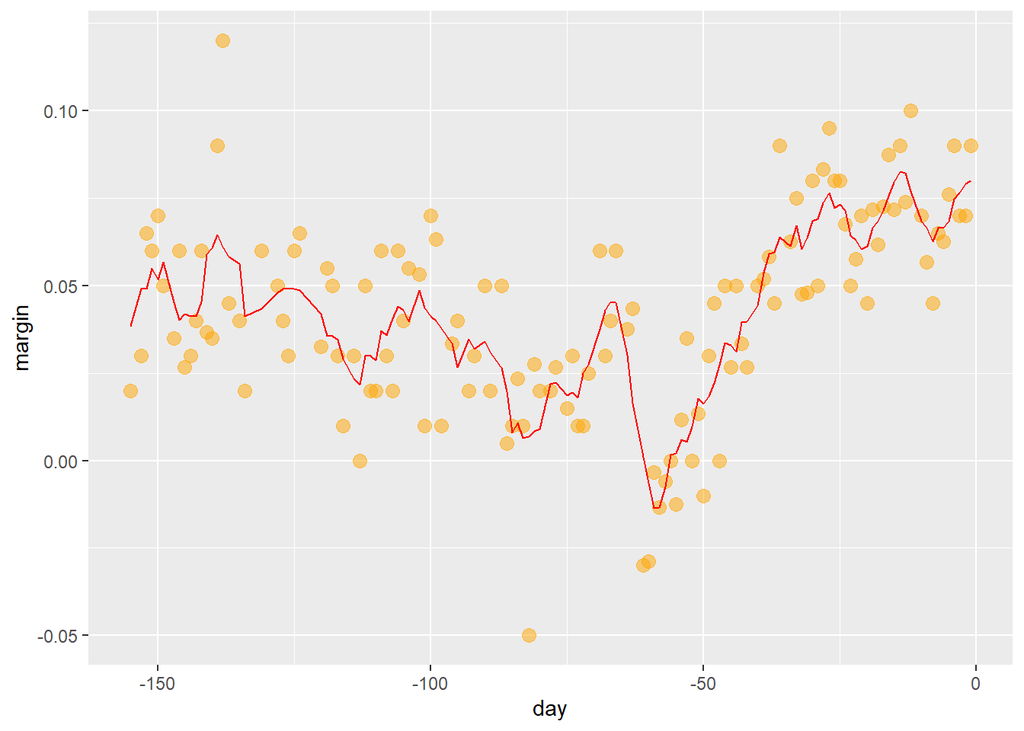

```r
span <- 7
fit <- with(polls_2008,
            ksmooth(day, margin, x.points = day, kernel = "box",
                    bandwidth = span))
polls_2008 %>% mutate(smooth = fit$y) %>%
  ggplot(aes(day, margin)) +
  geom_point(size = 3, alpha = 0.5, color = "orange") +
  geom_line(aes(day, smooth), color = "red")
```

Here, **Kernel**: Function to compute weighted averages.

{ 0: Points outside the window 1 / N0: Points inside the window }

**N0** - # of points in that week

With this, we can use Gaussian density to assign weights.

To change the kernel, just change the **kernel** parameter from **ksmooth** function.

# Final Result

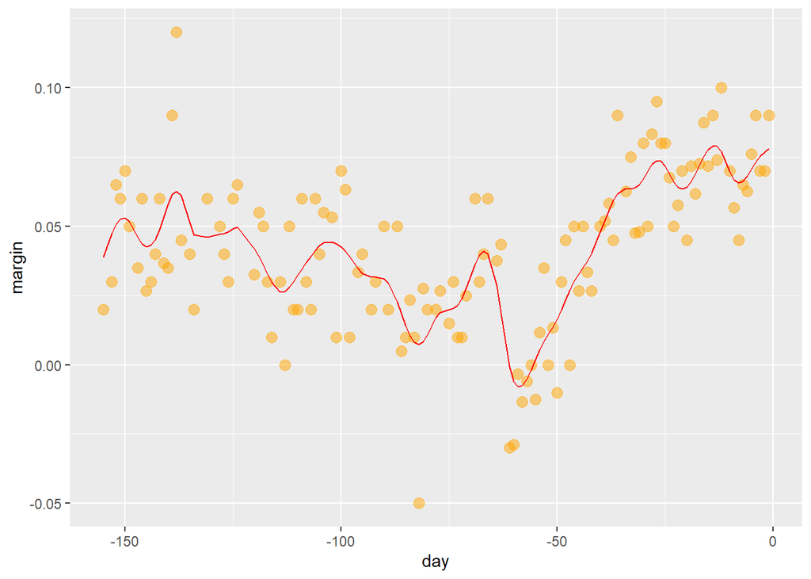

```r
span <- 7
fit <- with(polls_2008,
            ksmooth(day, margin, x.points = day, kernel = "normal",
                    bandwidth = span))
polls_2008 %>% mutate(smooth = fit$y) %>%
  ggplot(aes(day, margin)) +
  geom_point(size = 3, alpha = 0.5, color = "orange") +
  geom_line(aes(day, smooth), color = "red")
```

This is smoother. Change: **kernel = “normal”**

k-smooth fits a constant. So, it can be improved

**LOESS**: Local weighted regression

This make us consider larger windows

Now, assume function is *locally linear*

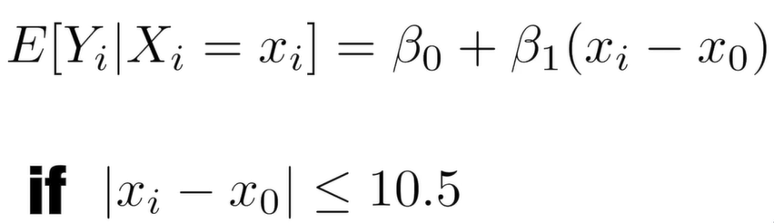

As a linear function